# Self_DGP_Arkhangelsky_Imbens_2022_Project

Omer Erhan Erbis 3466411

# Required Libraries

```r
rm(list = ls())

# Loading required libraries
library(mvtnorm)
library(pryr)
library(kableExtra)
```

## Simulation Functions

est_function() function performs k-means algrithm and clustering (also creating sufficient cluster-specific statistic $S_i$) that is in turn utilized in weight and treatment effect calculations for groups, eventually aggregating all the clusters with associated weights to calculate final treatment effect estimator.

```r
est_function <- function(W,Y,Z,K){

  ## This function takes assignment, data, aggregate shocks and number of clusters K

  n <- dim(W)[1]
  T <- dim(W)[2]

  # Sufficient cluster-specific statistic creation
  S <- W%*%Z/T
  # set.seed(1234)
  clust_res <- kmeans(S,K, iter.max = 20)
  clust_ind <- clust_res$cluster
  results_full <- matrix(0,ncol = 2, nrow = K)

  for(k in 1:K){

    index_k <- clust_ind == k
    if (sum(index_k) > 1){
      Y_k <- Y[index_k,]
      W_k <- W[index_k,]
      n_k <- sum(index_k)
      weights_k_unnorm <- W_k - outer(rep(1,n_k),colMeans(W_k)) - outer(rowMeans(W_k),rep(1,T)) + mean(W_k)
      weights_k <- weights_k_unnorm/(norm(weights_k_unnorm,'f')^2)
      tau_k <- sum(Y_k*weights_k)
      results_full[k,] <- c(tau_k,n_k)
    }
    else {
      results_full[k,] <- c(NA,NA)
    }
  }

  agg_tau <- weighted.mean(results_full[,1],results_full[,2],na.rm = TRUE)


  return(agg_tau)
}
```

### Reproducilbility

```r
# reproducibility
set.seed(1212)
```

# Data Generation Process

The simulation data is all random, with $n=200$ individual observation over $T=40$ periods.

As mentioned in the Arkhangelsky, Imbens (2022), the main problem with TWFE comes from the correlations of unobserved confounders $U_i$ with dependent variable $Y_{i t}$ and treatment assignment $W_{i t}$. To introduce this problem, the treatment assignment $W_{i t}$ has the following endogeneous component: I randomly generate and assign $unobserved\_types = 5$ different classes of $U_i$ on individuals $i$ that has associated discrete values $U_i \in \{1,2,3,4,5\}$. Each level of $U_i$ has arbitrary $unobserved\_effect\_on\_W = 0.01$ coefficient that demonstrates relative endogeneity impact on treatment assignment, chosen to have small-enough impact. The treatment assignment also has a random component, originated from a standard uniform distribution. The form of $W_{i t}$ is as follows:

$$W_{i t} = G_{i t} + unobserved\_effect\_on\_W \cdot U_{i} \; \; \; \; \; where \; \; G_{i t} \sim U(0,1)$$

The $\alpha(U_i)$ that is the individual-specific component depends on $U_i$ and has the arbitrary functional form of $\dfrac{U_i^2}{100}$ for introducing small-enough distortion.

I also generate year-time time-specific components $\lambda_t$ that holds $T \in \{1,2,3,...,40\}$ values for each year. Other time-varying components are possible for applications, but the simplest form is utilized here.

Treatment effect is assumed to have the value $\tau=1$.

With all these $Y_{i t}$ is defined as follows:

$$Y_{i t} = \alpha(U_i) + \tau \cdot W_{i t} + E_{i t}$$

where errors follow the standard normal distribution:

$$E_{i t} \sim N(0, 1)$$

```r
# Data dimensions
n <- 200
T <- 40
unobserved_types <- 5
unobserved_effect_on_W <- 0.01
# unobserved confounder U_i
U_i <- round(sample(1:unobserved_types, n, replace = T), 0)
U <- rep(U_i, T)
U_mat <- matrix(U, nrow = n, ncol = T)
# Assignment
W <- round(runif(n*T) + rep(U_i, T) * unobserved_effect_on_W, 0)
W_mat <- matrix(W, nrow = n, ncol = T)
# Constant for S_i creation
Z <- cbind(rep(1, T))
# S <- W%*%Z/T
# S_i <- rowSums(matrix(S, nrow = n, ncol = T))/T
# year-time time effect
lambda_t <- rep(1:T, n) + rnorm(n*T)
# random errors
E_y <- rnorm(n*T)
E_mat <- matrix(E_y, nrow = n, ncol = T)
# unit-fixed effect (arbitrary function choice of U_i)
alpha_i <- U_i^2/100
# treatment effect
tau <- 1
# dependent variable
Y <- rep(alpha_i, T) + tau * W + E_y
Y_mat <- matrix(Y, nrow = n, ncol = T)
```

# Correlations that Introduce the Endogeneity Problem

```r
cor(U, Y)
```

```
## [1] 0.07463778
```

```r
cor(U, W)
```

```
## [1] 0.03325911
```

# Simulation Parameters

```r
## Number of clusters
K_5 <- floor(n/12)
K_6 <- floor(n/16)
K_7 <- floor(n/24)
K_8 <- floor(n/32)
K_9 <- floor(n/75)
K_10 <- 1
# K_vec <- c(K_1, K_2, K_3, K_4, K_5, K_6, K_7, K_8)
K_vec <- c(K_5, K_6, K_7, K_8, K_9, K_10)

# number of simulations
B <- 10000
```

# Simulation

```r
# Simulations

# Design 1 Only - No Over-Selection



## Design 1 - No Selection Bias

tau_calc <- pryr::partial(est_function, W=W_mat,Y=Y_mat,Z=Z)

sim_res_1 <- do.call(rbind,lapply(1:B, function(b) {


  # tau_calc <- pryr::partial(est_function, W=W_b,Y=Y_b,Z=Z)
  a_tau_coll <- sapply(K_vec, FUN=tau_calc)

  return(a_tau_coll)
}))


predicted_treatmens <- colMeans(sim_res_1)
rmse_1 <- sqrt(colMeans((sim_res_1-tau)^2))
bias_1 <- colMeans(sim_res_1-tau)

# rmse_1
# bias_1




K_names <- paste0(K_vec, "cluster/s")
table_1 <- round(rbind(predicted_treatmens, rmse_1, bias_1),6)
colnames(table_1) <- c(K_names)
rownames(table_1) <- c('treatment_prediction','rmse_design_1','bias_design_1')

table_1 %>%
  kbl() %>%
  kable_styling()
```

|  | 16cluster/s | 12cluster/s | 8cluster/s | 6cluster/s | 2cluster/s | 1cluster/s |
| --- | --- | --- | --- | --- | --- | --- |
| treatment_prediction | 0.982938 | 0.987525 | 0.992030 | 0.993745 | 0.994633 | 0.992412 |
| rmse_design_1 | 0.017062 | 0.012665 | 0.008175 | 0.006497 | 0.005689 | 0.007588 |
| bias_design_1 | -0.017062 | -0.012475 | -0.007970 | -0.006255 | -0.005367 | -0.007588 |

# Plots

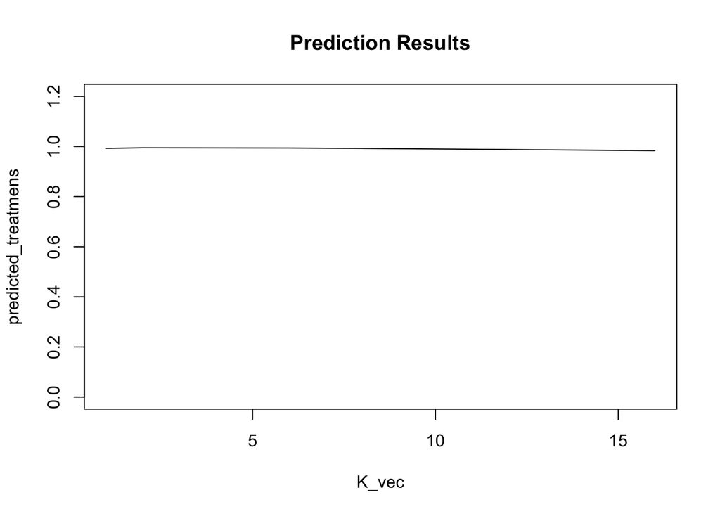

```r
# Plots

## Predictions
plot(K_vec, predicted_treatmens, col=("black"), main = "Prediction Results", pch = 1, type = "l", ylim = c(0, 1.2))
```

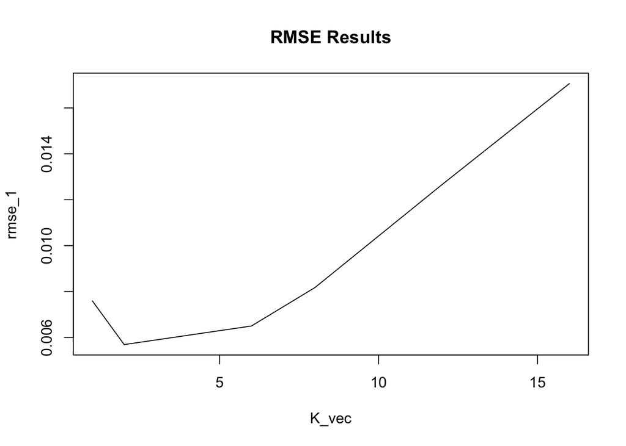

```r
## RMSE
plot(K_vec, rmse_1, col=("black"), main = "RMSE Results", pch = 1, type = "l")
```

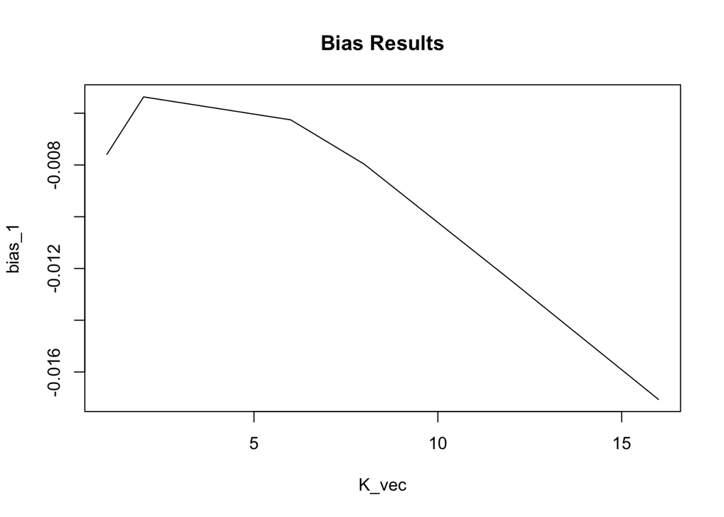

```r
## Bias
plot(K_vec, bias_1, col=("black"), main = "Bias Results", pch = 1, type = "l")
```